# Risk Factor Analysis

## Outcome Variable

**Outcome Variable:** ever_stunted

## Predictor Variables

**Intervention Variable:** mhtcm

**Adjustment Set:**

unadjusted

## Stratifying Variables

The analysis was stratified on these variable(s):

- agecat
- studyid
- country

## Data Summary

| agecat | studyid | country | mhtcm | ever_stunted | n_cell | n |
| --- | --- | --- | --- | --- | --- | --- |
| 0-6 months | ki0047075b-MAL-ED | BANGLADESH | >=160 | 0 | 4 | 254 |
| 0-6 months | ki0047075b-MAL-ED | BANGLADESH | >=160 | 1 | 0 | 254 |
| 0-6 months | ki0047075b-MAL-ED | BANGLADESH | <145 | 0 | 42 | 254 |
| 0-6 months | ki0047075b-MAL-ED | BANGLADESH | <145 | 1 | 14 | 254 |
| 0-6 months | ki0047075b-MAL-ED | BANGLADESH | [145-150) | 0 | 74 | 254 |
| 0-6 months | ki0047075b-MAL-ED | BANGLADESH | [145-150) | 1 | 17 | 254 |
| 0-6 months | ki0047075b-MAL-ED | BANGLADESH | [150-155) | 0 | 73 | 254 |
| 0-6 months | ki0047075b-MAL-ED | BANGLADESH | [150-155) | 1 | 9 | 254 |
| 0-6 months | ki0047075b-MAL-ED | BANGLADESH | [155-160) | 0 | 18 | 254 |
| 0-6 months | ki0047075b-MAL-ED | BANGLADESH | [155-160) | 1 | 3 | 254 |
| 0-6 months | ki0047075b-MAL-ED | BRAZIL | >=160 | 0 | 63 | 222 |
| 0-6 months | ki0047075b-MAL-ED | BRAZIL | >=160 | 1 | 5 | 222 |
| 0-6 months | ki0047075b-MAL-ED | BRAZIL | <145 | 0 | 7 | 222 |
| 0-6 months | ki0047075b-MAL-ED | BRAZIL | <145 | 1 | 1 | 222 |
| 0-6 months | ki0047075b-MAL-ED | BRAZIL | [145-150) | 0 | 27 | 222 |
| 0-6 months | ki0047075b-MAL-ED | BRAZIL | [145-150) | 1 | 6 | 222 |
| 0-6 months | ki0047075b-MAL-ED | BRAZIL | [150-155) | 0 | 47 | 222 |
| 0-6 months | ki0047075b-MAL-ED | BRAZIL | [150-155) | 1 | 4 | 222 |
| 0-6 months | ki0047075b-MAL-ED | BRAZIL | [155-160) | 0 | 55 | 222 |
| 0-6 months | ki0047075b-MAL-ED | BRAZIL | [155-160) | 1 | 7 | 222 |
| 0-6 months | ki0047075b-MAL-ED | INDIA | >=160 | 0 | 13 | 242 |
| 0-6 months | ki0047075b-MAL-ED | INDIA | >=160 | 1 | 1 | 242 |
| 0-6 months | ki0047075b-MAL-ED | INDIA | <145 | 0 | 25 | 242 |
| 0-6 months | ki0047075b-MAL-ED | INDIA | <145 | 1 | 4 | 242 |
| 0-6 months | ki0047075b-MAL-ED | INDIA | [145-150) | 0 | 55 | 242 |
| 0-6 months | ki0047075b-MAL-ED | INDIA | [145-150) | 1 | 15 | 242 |
| 0-6 months | ki0047075b-MAL-ED | INDIA | [150-155) | 0 | 70 | 242 |
| 0-6 months | ki0047075b-MAL-ED | INDIA | [150-155) | 1 | 18 | 242 |
| 0-6 months | ki0047075b-MAL-ED | INDIA | [155-160) | 0 | 38 | 242 |
| 0-6 months | ki0047075b-MAL-ED | INDIA | [155-160) | 1 | 3 | 242 |

[output cut: 643 more lines]

The following strata were considered:

- agecat: 0-24 months, studyid: ki0047075b-MAL-ED, country: BANGLADESH
- agecat: 0-24 months, studyid: ki0047075b-MAL-ED, country: BRAZIL
- agecat: 0-24 months, studyid: ki0047075b-MAL-ED, country: INDIA
- agecat: 0-24 months, studyid: ki0047075b-MAL-ED, country: NEPAL
- agecat: 0-24 months, studyid: ki0047075b-MAL-ED, country: PERU
- agecat: 0-24 months, studyid: ki0047075b-MAL-ED, country: SOUTH AFRICA
- agecat: 0-24 months, studyid: ki0047075b-MAL-ED, country: TANZANIA, UNITED REPUBLIC OF
- agecat: 0-24 months, studyid: ki1000304b-SAS-CompFeed, country: INDIA
- agecat: 0-24 months, studyid: ki1000304b-SAS-FoodSuppl, country: INDIA
- agecat: 0-24 months, studyid: ki1017093-NIH-Birth, country: BANGLADESH
- agecat: 0-24 months, studyid: ki1017093b-PROVIDE, country: BANGLADESH
- agecat: 0-24 months, studyid: ki1017093c-NIH-Crypto, country: BANGLADESH
- agecat: 0-24 months, studyid: ki1066203-TanzaniaChild2, country: TANZANIA, UNITED REPUBLIC OF
- agecat: 0-24 months, studyid: ki1101329-Keneba, country: GAMBIA
- agecat: 0-24 months, studyid: ki1112895-Guatemala BSC, country: GUATEMALA
- agecat: 0-24 months, studyid: ki1112895-iLiNS-Zinc, country: BURKINA FASO
- agecat: 0-24 months, studyid: ki1119695-PROBIT, country: BELARUS
- agecat: 0-24 months, studyid: ki1126311-ZVITAMBO, country: ZIMBABWE
- agecat: 0-24 months, studyid: ki1135781-COHORTS, country: GUATEMALA
- agecat: 0-24 months, studyid: ki1135781-COHORTS, country: INDIA
- agecat: 0-24 months, studyid: ki1135781-COHORTS, country: PHILIPPINES
- agecat: 0-24 months, studyid: ki1148112-LCNI-5, country: MALAWI
- agecat: 0-24 months, studyid: kiGH5241-JiVitA-3, country: BANGLADESH
- agecat: 0-6 months, studyid: ki0047075b-MAL-ED, country: BANGLADESH
- agecat: 0-6 months, studyid: ki0047075b-MAL-ED, country: BRAZIL
- agecat: 0-6 months, studyid: ki0047075b-MAL-ED, country: INDIA
- agecat: 0-6 months, studyid: ki0047075b-MAL-ED, country: NEPAL
- agecat: 0-6 months, studyid: ki0047075b-MAL-ED, country: PERU
- agecat: 0-6 months, studyid: ki0047075b-MAL-ED, country: SOUTH AFRICA
- agecat: 0-6 months, studyid: ki0047075b-MAL-ED, country: TANZANIA, UNITED REPUBLIC OF
- agecat: 0-6 months, studyid: ki1000304b-SAS-CompFeed, country: INDIA
- agecat: 0-6 months, studyid: ki1000304b-SAS-FoodSuppl, country: INDIA
- agecat: 0-6 months, studyid: ki1017093-NIH-Birth, country: BANGLADESH
- agecat: 0-6 months, studyid: ki1017093b-PROVIDE, country: BANGLADESH
- agecat: 0-6 months, studyid: ki1017093c-NIH-Crypto, country: BANGLADESH
- agecat: 0-6 months, studyid: ki1066203-TanzaniaChild2, country: TANZANIA, UNITED REPUBLIC OF
- agecat: 0-6 months, studyid: ki1101329-Keneba, country: GAMBIA
- agecat: 0-6 months, studyid: ki1112895-Guatemala BSC, country: GUATEMALA
- agecat: 0-6 months, studyid: ki1119695-PROBIT, country: BELARUS
- agecat: 0-6 months, studyid: ki1126311-ZVITAMBO, country: ZIMBABWE
- agecat: 0-6 months, studyid: ki1135781-COHORTS, country: GUATEMALA
- agecat: 0-6 months, studyid: ki1135781-COHORTS, country: INDIA
- agecat: 0-6 months, studyid: ki1135781-COHORTS, country: PHILIPPINES
- agecat: 0-6 months, studyid: ki1148112-LCNI-5, country: MALAWI
- agecat: 0-6 months, studyid: kiGH5241-JiVitA-3, country: BANGLADESH
- agecat: 6-24 months, studyid: ki0047075b-MAL-ED, country: BANGLADESH
- agecat: 6-24 months, studyid: ki0047075b-MAL-ED, country: BRAZIL
- agecat: 6-24 months, studyid: ki0047075b-MAL-ED, country: INDIA
- agecat: 6-24 months, studyid: ki0047075b-MAL-ED, country: NEPAL
- agecat: 6-24 months, studyid: ki0047075b-MAL-ED, country: PERU
- agecat: 6-24 months, studyid: ki0047075b-MAL-ED, country: SOUTH AFRICA
- agecat: 6-24 months, studyid: ki0047075b-MAL-ED, country: TANZANIA, UNITED REPUBLIC OF
- agecat: 6-24 months, studyid: ki1000304b-SAS-CompFeed, country: INDIA
- agecat: 6-24 months, studyid: ki1000304b-SAS-FoodSuppl, country: INDIA
- agecat: 6-24 months, studyid: ki1017093-NIH-Birth, country: BANGLADESH
- agecat: 6-24 months, studyid: ki1017093b-PROVIDE, country: BANGLADESH
- agecat: 6-24 months, studyid: ki1017093c-NIH-Crypto, country: BANGLADESH
- agecat: 6-24 months, studyid: ki1066203-TanzaniaChild2, country: TANZANIA, UNITED REPUBLIC OF
- agecat: 6-24 months, studyid: ki1101329-Keneba, country: GAMBIA
- agecat: 6-24 months, studyid: ki1112895-Guatemala BSC, country: GUATEMALA
- agecat: 6-24 months, studyid: ki1112895-iLiNS-Zinc, country: BURKINA FASO
- agecat: 6-24 months, studyid: ki1119695-PROBIT, country: BELARUS
- agecat: 6-24 months, studyid: ki1126311-ZVITAMBO, country: ZIMBABWE
- agecat: 6-24 months, studyid: ki1135781-COHORTS, country: GUATEMALA
- agecat: 6-24 months, studyid: ki1135781-COHORTS, country: INDIA
- agecat: 6-24 months, studyid: ki1135781-COHORTS, country: PHILIPPINES
- agecat: 6-24 months, studyid: ki1148112-LCNI-5, country: MALAWI
- agecat: 6-24 months, studyid: kiGH5241-JiVitA-3, country: BANGLADESH

### Dropped Strata

Some strata were dropped due to rare outcomes:

## Methods Detail

We’re interested in the causal parameters $E[Y_a]$ for all values of $a \in \mathcal{A}$. These parameters represent the mean outcome if, possibly contrary to fact, we intervened to set all units to have $A=a$. Under the randomization and positivity assumptions, these are identified by the statistical parameters $\psi_a=E_W[E_{Y|A,W}(Y|A=a,W)]$. In addition, we’re interested in the mean of $Y$, $E[Y]$ under no intervention (the observed mean). We will estimate these parameters by using SuperLearner to fit the relevant likelihood factors – $E_{Y|A,W}(Y|A=a,W)$ and $p(A=a|W)$, and then updating our likelihood fit using a joint TMLE.

For unadjusted analyses ($W=\{\}$), initial likelihoods were estimated using Lrnr_glm to estimate the simple $E(Y|A)$ and Lrnr_mean to estimate $p(A)$. For adjusted analyses, a small library containing Lrnr_glmnet, Lrnr_xgboost, and Lrnr_mean was used.

Having estimated these parameters, we will then use the delta method to estimate relative risks and attributable risks relative to a prespecified baseline level of $A$.

```
##            ever_stunted
## mhtcm         0
##   >=160     136
##   <145      116
##   [145-150) 392
##   [150-155) 531
##   [155-160) 360
```

# Results Detail

## Results Plots

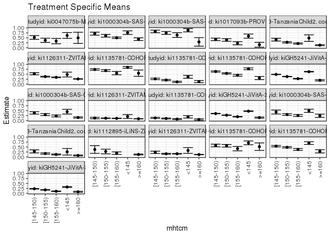

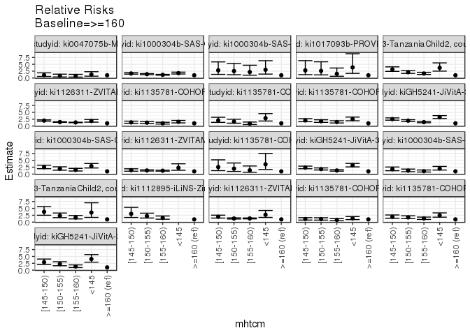

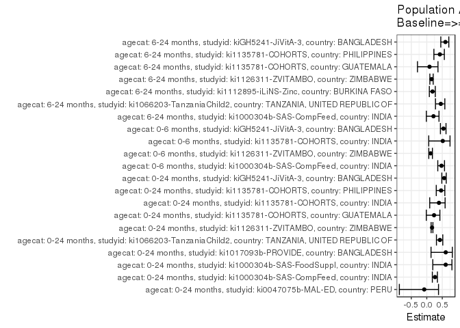

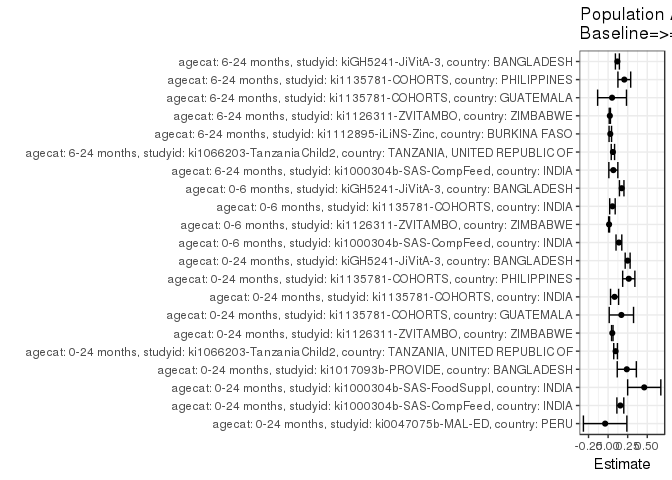

## Results Table

### Parameter: TSM

| agecat | studyid | country | intervention_level | baseline_level | estimate | ci_lower | ci_upper |
| --- | --- | --- | --- | --- | --- | --- | --- |
| 0-24 months | ki0047075b-MAL-ED | PERU | >=160 | NA | 0.5000000 | 0.2166145 | 0.7833855 |
| 0-24 months | ki0047075b-MAL-ED | PERU | <145 | NA | 0.6190476 | 0.4719279 | 0.7661673 |
| 0-24 months | ki0047075b-MAL-ED | PERU | [145-150) | NA | 0.5185185 | 0.4241215 | 0.6129155 |
| 0-24 months | ki0047075b-MAL-ED | PERU | [150-155) | NA | 0.3750000 | 0.2687305 | 0.4812695 |
| 0-24 months | ki0047075b-MAL-ED | PERU | [155-160) | NA | 0.3333333 | 0.1997442 | 0.4669225 |
| 0-24 months | ki1000304b-SAS-CompFeed | INDIA | >=160 | NA | 0.4315789 | 0.3626119 | 0.5005460 |
| 0-24 months | ki1000304b-SAS-CompFeed | INDIA | <145 | NA | 0.7603306 | 0.6693218 | 0.8513393 |
| 0-24 months | ki1000304b-SAS-CompFeed | INDIA | [145-150) | NA | 0.7111913 | 0.6354269 | 0.7869558 |
| 0-24 months | ki1000304b-SAS-CompFeed | INDIA | [150-155) | NA | 0.6041190 | 0.5372988 | 0.6709392 |
| 0-24 months | ki1000304b-SAS-CompFeed | INDIA | [155-160) | NA | 0.5026178 | 0.4642693 | 0.5409663 |
| 0-24 months | ki1000304b-SAS-FoodSuppl | INDIA | >=160 | NA | 0.2941176 | 0.0772564 | 0.5109789 |
| 0-24 months | ki1000304b-SAS-FoodSuppl | INDIA | <145 | NA | 0.8833333 | 0.8020054 | 0.9646613 |
| 0-24 months | ki1000304b-SAS-FoodSuppl | INDIA | [145-150) | NA | 0.8217054 | 0.7555734 | 0.8878375 |
| 0-24 months | ki1000304b-SAS-FoodSuppl | INDIA | [150-155) | NA | 0.7464789 | 0.6748396 | 0.8181182 |
| 0-24 months | ki1000304b-SAS-FoodSuppl | INDIA | [155-160) | NA | 0.6393443 | 0.5186939 | 0.7599946 |
| 0-24 months | ki1017093b-PROVIDE | BANGLADESH | >=160 | NA | 0.1515152 | 0.0290913 | 0.2739390 |
| 0-24 months | ki1017093b-PROVIDE | BANGLADESH | <145 | NA | 0.5862069 | 0.4826378 | 0.6897760 |
| 0-24 months | ki1017093b-PROVIDE | BANGLADESH | [145-150) | NA | 0.4212766 | 0.3580997 | 0.4844535 |
| 0-24 months | ki1017093b-PROVIDE | BANGLADESH | [150-155) | NA | 0.3923445 | 0.3260981 | 0.4585909 |
| 0-24 months | ki1017093b-PROVIDE | BANGLADESH | [155-160) | NA | 0.2285714 | 0.1481934 | 0.3089494 |
| 0-24 months | ki1066203-TanzaniaChild2 | TANZANIA, UNITED REPUBLIC OF | >=160 | NA | 0.1303704 | 0.1049639 | 0.1557769 |
| 0-24 months | ki1066203-TanzaniaChild2 | TANZANIA, UNITED REPUBLIC OF | <145 | NA | 0.4857143 | 0.3200996 | 0.6513290 |
| 0-24 months | ki1066203-TanzaniaChild2 | TANZANIA, UNITED REPUBLIC OF | [145-150) | NA | 0.4076087 | 0.3365925 | 0.4786249 |
| 0-24 months | ki1066203-TanzaniaChild2 | TANZANIA, UNITED REPUBLIC OF | [150-155) | NA | 0.2753846 | 0.2410362 | 0.3097331 |
| 0-24 months | ki1066203-TanzaniaChild2 | TANZANIA, UNITED REPUBLIC OF | [155-160) | NA | 0.2134969 | 0.1853580 | 0.2416359 |
| 0-24 months | ki1126311-ZVITAMBO | ZIMBABWE | >=160 | NA | 0.2622186 | 0.2499414 | 0.2744958 |
| 0-24 months | ki1126311-ZVITAMBO | ZIMBABWE | <145 | NA | 0.4843750 | 0.3619309 | 0.6068191 |
| 0-24 months | ki1126311-ZVITAMBO | ZIMBABWE | [145-150) | NA | 0.5236593 | 0.4686769 | 0.5786417 |
| 0-24 months | ki1126311-ZVITAMBO | ZIMBABWE | [150-155) | NA | 0.3811275 | 0.3575636 | 0.4046913 |
| 0-24 months | ki1126311-ZVITAMBO | ZIMBABWE | [155-160) | NA | 0.3435351 | 0.3262741 | 0.3607960 |

[output cut: 74 more lines]

### Parameter: E(Y)

| agecat | studyid | country | intervention_level | baseline_level | estimate | ci_lower | ci_upper |
| --- | --- | --- | --- | --- | --- | --- | --- |
| 0-24 months | ki0047075b-MAL-ED | PERU | NA | NA | 0.4620690 | 0.4045891 | 0.5195488 |
| 0-24 months | ki1000304b-SAS-CompFeed | INDIA | NA | NA | 0.5877754 | 0.5430036 | 0.6325472 |
| 0-24 months | ki1000304b-SAS-FoodSuppl | INDIA | NA | NA | 0.7555012 | 0.7137976 | 0.7972049 |
| 0-24 months | ki1017093b-PROVIDE | BANGLADESH | NA | NA | 0.3901345 | 0.3531446 | 0.4271245 |
| 0-24 months | ki1066203-TanzaniaChild2 | TANZANIA, UNITED REPUBLIC OF | NA | NA | 0.2259432 | 0.2090636 | 0.2428228 |
| 0-24 months | ki1126311-ZVITAMBO | ZIMBABWE | NA | NA | 0.3157734 | 0.3065944 | 0.3249525 |
| 0-24 months | ki1135781-COHORTS | GUATEMALA | NA | NA | 0.7221362 | 0.6977013 | 0.7465711 |
| 0-24 months | ki1135781-COHORTS | INDIA | NA | NA | 0.2109129 | 0.1925934 | 0.2292325 |
| 0-24 months | ki1135781-COHORTS | PHILIPPINES | NA | NA | 0.5716154 | 0.5540738 | 0.5891570 |
| 0-24 months | kiGH5241-JiVitA-3 | BANGLADESH | NA | NA | 0.4439035 | 0.4363886 | 0.4514185 |
| 0-6 months | ki1000304b-SAS-CompFeed | INDIA | NA | NA | 0.2905983 | 0.2613336 | 0.3198630 |
| 0-6 months | ki1126311-ZVITAMBO | ZIMBABWE | NA | NA | 0.1014228 | 0.0954577 | 0.1073879 |
| 0-6 months | ki1135781-COHORTS | INDIA | NA | NA | 0.1073718 | 0.0933439 | 0.1213997 |
| 0-6 months | kiGH5241-JiVitA-3 | BANGLADESH | NA | NA | 0.3217983 | 0.3150446 | 0.3285520 |
| 6-24 months | ki1000304b-SAS-CompFeed | INDIA | NA | NA | 0.3087401 | 0.2746057 | 0.3428745 |
| 6-24 months | ki1066203-TanzaniaChild2 | TANZANIA, UNITED REPUBLIC OF | NA | NA | 0.1357889 | 0.1200421 | 0.1515357 |
| 6-24 months | ki1112895-iLiNS-Zinc | BURKINA FASO | NA | NA | 0.1520334 | 0.1259980 | 0.1780689 |
| 6-24 months | ki1126311-ZVITAMBO | ZIMBABWE | NA | NA | 0.1426075 | 0.1346615 | 0.1505536 |
| 6-24 months | ki1135781-COHORTS | GUATEMALA | NA | NA | 0.5690516 | 0.5294273 | 0.6086758 |
| 6-24 months | ki1135781-COHORTS | PHILIPPINES | NA | NA | 0.4901079 | 0.4693271 | 0.5108888 |
| 6-24 months | kiGH5241-JiVitA-3 | BANGLADESH | NA | NA | 0.1971650 | 0.1890838 | 0.2052463 |

### Parameter: RR

| agecat | studyid | country | intervention_level | baseline_level | estimate | ci_lower | ci_upper |
| --- | --- | --- | --- | --- | --- | --- | --- |
| 0-24 months | ki0047075b-MAL-ED | PERU | >=160 | >=160 | 1.0000000 | 1.0000000 | 1.000000 |
| 0-24 months | ki0047075b-MAL-ED | PERU | <145 | >=160 | 1.2380952 | 0.6696458 | 2.289090 |
| 0-24 months | ki0047075b-MAL-ED | PERU | [145-150) | >=160 | 1.0370370 | 0.5718241 | 1.880728 |
| 0-24 months | ki0047075b-MAL-ED | PERU | [150-155) | >=160 | 0.7500000 | 0.3979809 | 1.413384 |
| 0-24 months | ki0047075b-MAL-ED | PERU | [155-160) | >=160 | 0.6666667 | 0.3329993 | 1.334671 |
| 0-24 months | ki1000304b-SAS-CompFeed | INDIA | >=160 | >=160 | 1.0000000 | 1.0000000 | 1.000000 |
| 0-24 months | ki1000304b-SAS-CompFeed | INDIA | <145 | >=160 | 1.7617416 | 1.4569152 | 2.130346 |
| 0-24 months | ki1000304b-SAS-CompFeed | INDIA | [145-150) | >=160 | 1.6478824 | 1.4098513 | 1.926101 |
| 0-24 months | ki1000304b-SAS-CompFeed | INDIA | [150-155) | >=160 | 1.3997879 | 1.2221903 | 1.603192 |
| 0-24 months | ki1000304b-SAS-CompFeed | INDIA | [155-160) | >=160 | 1.1646022 | 1.0238196 | 1.324744 |
| 0-24 months | ki1000304b-SAS-FoodSuppl | INDIA | >=160 | >=160 | 1.0000000 | 1.0000000 | 1.000000 |
| 0-24 months | ki1000304b-SAS-FoodSuppl | INDIA | <145 | >=160 | 3.0033333 | 1.4285623 | 6.314048 |
| 0-24 months | ki1000304b-SAS-FoodSuppl | INDIA | [145-150) | >=160 | 2.7937984 | 1.3306860 | 5.865629 |
| 0-24 months | ki1000304b-SAS-FoodSuppl | INDIA | [150-155) | >=160 | 2.5380282 | 1.2066403 | 5.338448 |
| 0-24 months | ki1000304b-SAS-FoodSuppl | INDIA | [155-160) | >=160 | 2.1737705 | 1.0154879 | 4.653210 |
| 0-24 months | ki1017093b-PROVIDE | BANGLADESH | >=160 | >=160 | 1.0000000 | 1.0000000 | 1.000000 |
| 0-24 months | ki1017093b-PROVIDE | BANGLADESH | <145 | >=160 | 3.8689655 | 1.6919796 | 8.846971 |
| 0-24 months | ki1017093b-PROVIDE | BANGLADESH | [145-150) | >=160 | 2.7804255 | 1.2223895 | 6.324307 |
| 0-24 months | ki1017093b-PROVIDE | BANGLADESH | [150-155) | >=160 | 2.5894737 | 1.1342864 | 5.911535 |
| 0-24 months | ki1017093b-PROVIDE | BANGLADESH | [155-160) | >=160 | 1.5085714 | 0.6249769 | 3.641395 |
| 0-24 months | ki1066203-TanzaniaChild2 | TANZANIA, UNITED REPUBLIC OF | >=160 | >=160 | 1.0000000 | 1.0000000 | 1.000000 |
| 0-24 months | ki1066203-TanzaniaChild2 | TANZANIA, UNITED REPUBLIC OF | <145 | >=160 | 3.7256494 | 2.5155911 | 5.517774 |
| 0-24 months | ki1066203-TanzaniaChild2 | TANZANIA, UNITED REPUBLIC OF | [145-150) | >=160 | 3.1265440 | 2.4073409 | 4.060612 |
| 0-24 months | ki1066203-TanzaniaChild2 | TANZANIA, UNITED REPUBLIC OF | [150-155) | >=160 | 2.1123252 | 1.6760039 | 2.662236 |
| 0-24 months | ki1066203-TanzaniaChild2 | TANZANIA, UNITED REPUBLIC OF | [155-160) | >=160 | 1.6376185 | 1.2943114 | 2.071985 |
| 0-24 months | ki1126311-ZVITAMBO | ZIMBABWE | >=160 | >=160 | 1.0000000 | 1.0000000 | 1.000000 |
| 0-24 months | ki1126311-ZVITAMBO | ZIMBABWE | <145 | >=160 | 1.8472182 | 1.4284552 | 2.388745 |
| 0-24 months | ki1126311-ZVITAMBO | ZIMBABWE | [145-150) | >=160 | 1.9970333 | 1.7801543 | 2.240335 |
| 0-24 months | ki1126311-ZVITAMBO | ZIMBABWE | [150-155) | >=160 | 1.4534721 | 1.3450093 | 1.570682 |
| 0-24 months | ki1126311-ZVITAMBO | ZIMBABWE | [155-160) | >=160 | 1.3101094 | 1.2231535 | 1.403247 |

[output cut: 74 more lines]

### Parameter: PAR

| agecat | studyid | country | intervention_level | baseline_level | estimate | ci_lower | ci_upper |
| --- | --- | --- | --- | --- | --- | --- | --- |
| 0-24 months | ki0047075b-MAL-ED | PERU | >=160 | NA | -0.0379310 | -0.3153569 | 0.2394949 |
| 0-24 months | ki1000304b-SAS-CompFeed | INDIA | >=160 | NA | 0.1561965 | 0.1121890 | 0.2002040 |
| 0-24 months | ki1000304b-SAS-FoodSuppl | INDIA | >=160 | NA | 0.4613836 | 0.2495853 | 0.6731818 |
| 0-24 months | ki1017093b-PROVIDE | BANGLADESH | >=160 | NA | 0.2386194 | 0.1166470 | 0.3605918 |
| 0-24 months | ki1066203-TanzaniaChild2 | TANZANIA, UNITED REPUBLIC OF | >=160 | NA | 0.0955728 | 0.0718871 | 0.1192585 |
| 0-24 months | ki1126311-ZVITAMBO | ZIMBABWE | >=160 | NA | 0.0535548 | 0.0443842 | 0.0627255 |
| 0-24 months | ki1135781-COHORTS | GUATEMALA | >=160 | NA | 0.1695046 | 0.0141410 | 0.3248682 |
| 0-24 months | ki1135781-COHORTS | INDIA | >=160 | NA | 0.0827078 | 0.0313409 | 0.1340747 |
| 0-24 months | ki1135781-COHORTS | PHILIPPINES | >=160 | NA | 0.2639231 | 0.1860193 | 0.3418270 |
| 0-24 months | kiGH5241-JiVitA-3 | BANGLADESH | >=160 | NA | 0.2495373 | 0.2181186 | 0.2809561 |
| 0-6 months | ki1000304b-SAS-CompFeed | INDIA | >=160 | NA | 0.1379667 | 0.1011476 | 0.1747859 |
| 0-6 months | ki1126311-ZVITAMBO | ZIMBABWE | >=160 | NA | 0.0127098 | 0.0067512 | 0.0186685 |
| 0-6 months | ki1135781-COHORTS | INDIA | >=160 | NA | 0.0554237 | 0.0204422 | 0.0904053 |
| 0-6 months | kiGH5241-JiVitA-3 | BANGLADESH | >=160 | NA | 0.1734932 | 0.1446697 | 0.2023167 |
| 6-24 months | ki1000304b-SAS-CompFeed | INDIA | >=160 | NA | 0.0669100 | 0.0094558 | 0.1243642 |
| 6-24 months | ki1066203-TanzaniaChild2 | TANZANIA, UNITED REPUBLIC OF | >=160 | NA | 0.0614395 | 0.0402547 | 0.0826242 |
| 6-24 months | ki1112895-iLiNS-Zinc | BURKINA FASO | >=160 | NA | 0.0281252 | 0.0123079 | 0.0439424 |
| 6-24 months | ki1126311-ZVITAMBO | ZIMBABWE | >=160 | NA | 0.0220567 | 0.0143450 | 0.0297684 |
| 6-24 months | ki1135781-COHORTS | GUATEMALA | >=160 | NA | 0.0505331 | -0.1337296 | 0.2347957 |
| 6-24 months | ki1135781-COHORTS | PHILIPPINES | >=160 | NA | 0.2069221 | 0.1254719 | 0.2883722 |
| 6-24 months | kiGH5241-JiVitA-3 | BANGLADESH | >=160 | NA | 0.1186896 | 0.0932797 | 0.1440996 |

### Parameter: PAF

| agecat | studyid | country | intervention_level | baseline_level | estimate | ci_lower | ci_upper |
| --- | --- | --- | --- | --- | --- | --- | --- |
| 0-24 months | ki0047075b-MAL-ED | PERU | >=160 | NA | -0.0820896 | -0.8847867 | 0.3787532 |
| 0-24 months | ki1000304b-SAS-CompFeed | INDIA | >=160 | NA | 0.2657417 | 0.1795445 | 0.3428831 |
| 0-24 months | ki1000304b-SAS-FoodSuppl | INDIA | >=160 | NA | 0.6106986 | 0.1942686 | 0.8119031 |
| 0-24 months | ki1017093b-PROVIDE | BANGLADESH | >=160 | NA | 0.6116336 | 0.1373845 | 0.8251498 |
| 0-24 months | ki1066203-TanzaniaChild2 | TANZANIA, UNITED REPUBLIC OF | >=160 | NA | 0.4229949 | 0.3118740 | 0.5161717 |
| 0-24 months | ki1126311-ZVITAMBO | ZIMBABWE | >=160 | NA | 0.1695989 | 0.1401445 | 0.1980443 |
| 0-24 months | ki1135781-COHORTS | GUATEMALA | >=160 | NA | 0.2347267 | -0.0142828 | 0.4226036 |
| 0-24 months | ki1135781-COHORTS | INDIA | >=160 | NA | 0.3921419 | 0.0949870 | 0.5917280 |
| 0-24 months | ki1135781-COHORTS | PHILIPPINES | >=160 | NA | 0.4617145 | 0.3062072 | 0.5823662 |
| 0-24 months | kiGH5241-JiVitA-3 | BANGLADESH | >=160 | NA | 0.5621431 | 0.4854352 | 0.6274160 |
| 0-6 months | ki1000304b-SAS-CompFeed | INDIA | >=160 | NA | 0.4747678 | 0.3550722 | 0.5722484 |
| 0-6 months | ki1126311-ZVITAMBO | ZIMBABWE | >=160 | NA | 0.1253152 | 0.0649445 | 0.1817881 |
| 0-6 months | ki1135781-COHORTS | INDIA | >=160 | NA | 0.5161853 | 0.0634279 | 0.7500709 |
| 0-6 months | kiGH5241-JiVitA-3 | BANGLADESH | >=160 | NA | 0.5391365 | 0.4404860 | 0.6203935 |
| 6-24 months | ki1000304b-SAS-CompFeed | INDIA | >=160 | NA | 0.2167195 | -0.0129023 | 0.3942868 |
| 6-24 months | ki1066203-TanzaniaChild2 | TANZANIA, UNITED REPUBLIC OF | >=160 | NA | 0.4524630 | 0.2818377 | 0.5825501 |
| 6-24 months | ki1112895-iLiNS-Zinc | BURKINA FASO | >=160 | NA | 0.1849932 | 0.0830313 | 0.2756175 |
| 6-24 months | ki1126311-ZVITAMBO | ZIMBABWE | >=160 | NA | 0.1546674 | 0.0993524 | 0.2065851 |
| 6-24 months | ki1135781-COHORTS | GUATEMALA | >=160 | NA | 0.0888023 | -0.3001238 | 0.3613829 |
| 6-24 months | ki1135781-COHORTS | PHILIPPINES | >=160 | NA | 0.4221970 | 0.2295007 | 0.5667013 |
| 6-24 months | kiGH5241-JiVitA-3 | BANGLADESH | >=160 | NA | 0.6019811 | 0.4521164 | 0.7108528 |